# Stat 151A Lab 7

Stephanie DeGraaf

October 5, 2018

## Bootstrap Resampling

Recall the linear model setup:
$$Y = X\beta + e.$$
Our only assumptions for the linear model are that the errors $e_i$ are iid with mean zero and common variance $\sigma^2$.

Importantly, we do not assume normality of the errors. Adding the assumption of normality allows us to conduct statistical significance tests based on a normal distribution.

However, we can also conduct tests of significance without assuming normality. The bootstrap method allows us to do this.

### Bootstrapping Residuals

To use the bootstrap, we assume the errors come from some arbitrary distribution $F$ with $\mathbb{E}(e_i) = 0$. We use the bootstrap with empirical distribution $\hat F$ as the distribution of $e_i$.

1. Fit a regression on the data to obtain $\hat y = X\hat \beta$ and $\hat e = y - \hat y$.
2. Sample $n$ residuals $e^* = (e_1^*, ... , e_n^*)$ with replacement from the original residuals $\hat e = (\hat e_1, ..., \hat e_n)$.
3. create a new response vector using the new residuals: $y^* = \hat y + e^*$.
4. Fit a new regression using the new response vector $y^*$ to generate a new estimate of the coefficients $\hat \beta$.
5. Repeat steps 2-4 many times to get a bootstrap distribution of $\hat \beta$.

### Example: GPA dataset

Consider a dataset studying the college GPAS of 141 MSU students from 1994. Suppose we are interested in studying the effect of skipping lectures on GPA.

Model college GPA by high school GPA and skipped (avg number of lectures missed per week).

```r
library(wooldridge)
data("gpa1")
head(gpa1)
```

```
##   age soph junior senior senior5 male campus business engineer colGPA
## 1  21    0      0      1       0    0      0        1        0    3.0
## 2  21    0      0      1       0    0      0        1        0    3.4
## 3  20    0      1      0       0    0      0        1        0    3.0
## 4  19    1      0      0       0    1      1        1        0    3.5
## 5  20    0      1      0       0    0      0        1        0    3.6
## 6  20    0      0      1       0    1      1        1        0    3.0
##   hsGPA ACT job19 job20 drive bike walk voluntr PC greek car siblings
## 1   3.0  21     0     1     1    0    0       0  0     0   1        1
## 2   3.2  24     0     1     1    0    0       0  0     0   1        0
## 3   3.6  26     1     0     0    0    1       0  0     0   1        1
## 4   3.5  27     1     0     0    0    1       0  0     0   0        1
## 5   3.9  28     0     1     0    1    0       0  0     0   1        1
## 6   3.4  25     0     0     0    0    1       0  0     0   1        1
##   bgfriend clubs skipped alcohol gradMI fathcoll mothcoll
## 1        0     0       2     1.0      1        0        0
## 2        1     1       0     1.0      1        1        1
## 3        0     1       0     1.0      1        1        1
## 4        0     0       0     0.0      0        0        0
## 5        1     0       0     1.5      1        1        0
## 6        0     0       0     0.0      0        1        0
```

```r
model<- lm(colGPA ~ hsGPA + skipped, data = gpa1)
summary(model)
```

```
##
## Call:
## lm(formula = colGPA ~ hsGPA + skipped, data = gpa1)
##
## Residuals:
##      Min       1Q   Median       3Q      Max
## -0.85343 -0.23910 -0.03011  0.24442  0.86774
##
## Coefficients:
##             Estimate Std. Error t value Pr(>|t|)
## (Intercept)  1.57917    0.30337   5.205 6.87e-07 ***
## hsGPA        0.45880    0.08769   5.232 6.09e-07 ***
## skipped     -0.07743    0.02576  -3.005  0.00315 **
## ---
## Signif. codes:  0 '***' 0.001 '**' 0.01 '*' 0.05 '.' 0.1 ' ' 1
##
## Residual standard error: 0.3306 on 138 degrees of freedom
## Multiple R-squared:  0.2227, Adjusted R-squared:  0.2115
## F-statistic: 19.77 on 2 and 138 DF,  p-value: 2.814e-08
```

```r
residuals<- model$residuals
yhat<- model$fitted.values
coefs<- model$coefficients
n<- nrow(gpa1)

B = 5000
results<- matrix(NA, nrow = B, ncol = length(coefs))
for (rep in 1:B){
  boot.resid<- sample(residuals, n, replace = T)
  gpa1$colGPA_boot<- yhat + boot.resid
  boot.model<- lm(colGPA_boot ~ hsGPA + skipped, data = gpa1)
  boot.coefs<- boot.model$coefficients
  results[rep,]<- boot.coefs
}
```

Plot the results:

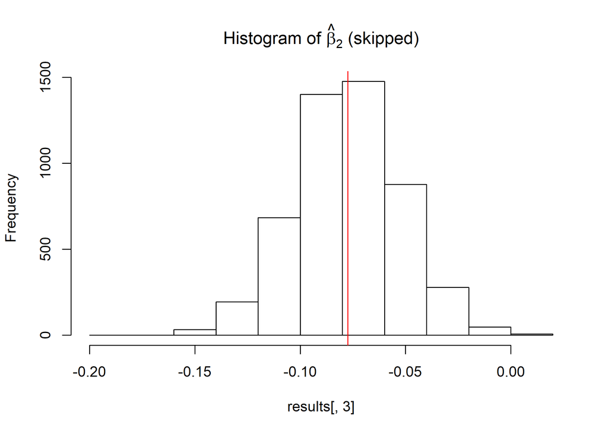

```r
hist(results[,3], main = expression(paste("Histogram of ", hat(beta)[2], " (skipped)")))
abline(v=coefs[3], col = "red")
```

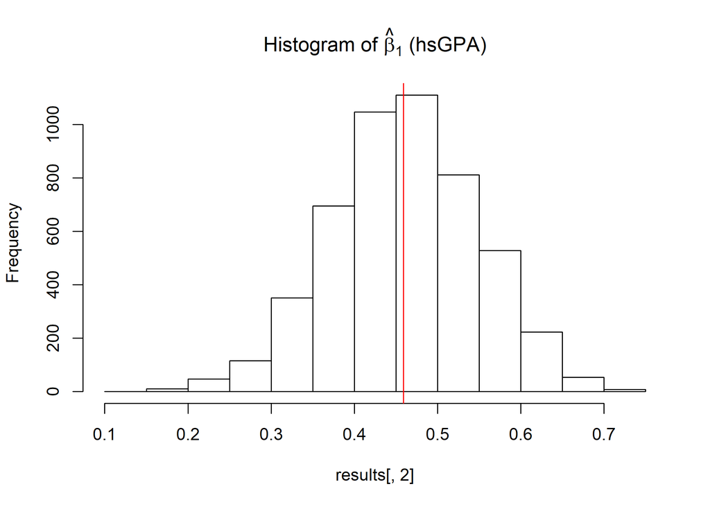

```r
hist(results[,2], main = expression(paste("Histogram of ", hat(beta)[1], " (hsGPA)")))
abline(v=coefs[2], col = "red")
```

### Bootstrap confidence intervals

There are a few ways to create a confidence interval:

Percentile Confidence Interval: use the 0.025 and 0.975 percentiles of the bootstrap distribution

```r
lwr<- quantile(results[,3], 0.025)
upr<- quantile(results[,3], 0.975)
c(lwr, upr)
```

```
##       2.5%      97.5%
## -0.1263278 -0.0284723
```

Bootstrap Confidence Interval: estimate the standard error of $\hat \beta$ by the standard deviation of $\hat \beta^{(j)} - \hat \beta$

```r
se<- sd(results[,3] - coefs[3])
lwr<- coefs[3] - 1.96*se
upr<- coefs[3] + 1.96*se
c(lwr, upr)
```

```
##     skipped     skipped
## -0.12672205 -0.02814768
```

## Midterm Review

See practice problems.

## Homework 3

Discuss lingering problems.